# Intro_DS_TextMining

Ali Rivera

2023-08-25

```r
library(tidyverse)
```

```r
library(tidytext)
library(wordcloud)
```

First, we read in all .txt files (you can do this individually with `as.tibble(read_lines("file_name.txt)`) in the current working directory. **Note: This means the file must be saved in the same folder as the .txt files.**

```r
## Get list of all file names in folder
files = list.files()

## Make a large list with text from each files (n=number of files)
all_data <- list()
all_data <- lapply(files, readr::read_lines)

## Rename index (?) with file names -.txt
names(all_data) <- gsub("\\.txt$", "", files)

## List of school names to use later
schools <- names(all_data)
schools <-  Filter(function(x) !any(grep("TextMiningExploration", x)), schools)
```

Then we make a data frame for each syllabus, and for each data frame use `unnest_tokens(word, value)` to separate each word, and `anti_join(stop_words)` to remove the stop words (common words like: it, the, to, etc.), and `filter(is.na(as.numeric(word)))` to remove numeric tokens.

```r
ASU_df <- data_frame(as.tibble(all_data$ASU))
ASU_df <- ASU_df %>%
  unnest_tokens(word, value) %>%
  anti_join(stop_words) %>%
  filter(is.na(as.numeric(word)))

Boston_Uni_df <- data_frame(as.tibble(all_data$Boston_Uni))
Boston_Uni_df <- Boston_Uni_df %>%
  unnest_tokens(word, value) %>%
  anti_join(stop_words) %>%
  filter(is.na(as.numeric(word)))

Brown_df <- data_frame(as.tibble(all_data$Brown))
Brown_df <- Brown_df %>%
  unnest_tokens(word, value) %>%
  anti_join(stop_words) %>%
  filter(is.na(as.numeric(word)))

Cornell_df <- data_frame(as.tibble(all_data$Cornell))
Cornell_df <- Cornell_df %>%
  unnest_tokens(word, value) %>%
  anti_join(stop_words) %>%
  filter(is.na(as.numeric(word)))

CUNY_df <- data_frame(as.tibble(all_data$CUNY))
CUNY_df <- CUNY_df %>%
  unnest_tokens(word, value) %>%
  anti_join(stop_words) %>%
  filter(is.na(as.numeric(word)))

Drexel_df <- data_frame(as.tibble(all_data$Drexel))
Drexel_df <- Drexel_df %>%
  unnest_tokens(word, value) %>%
  anti_join(stop_words) %>%
  filter(is.na(as.numeric(word)))

Georgia_Tech_df <- data_frame(as.tibble(all_data$Georgia_Tech))
Georgia_Tech_df <- Georgia_Tech_df %>%
  unnest_tokens(word, value) %>%
  anti_join(stop_words) %>%
  filter(is.na(as.numeric(word)))

Harvard_df <- data_frame(as.tibble(all_data$Harvard))
Harvard_df <- Harvard_df %>%
  unnest_tokens(word, value) %>%
  anti_join(stop_words) %>%
  filter(is.na(as.numeric(word)))

LSU_df <- data_frame(as.tibble(all_data$LSU))
LSU_df <- LSU_df %>%
  unnest_tokens(word, value) %>%
  anti_join(stop_words) %>%
  filter(is.na(as.numeric(word)))

MIT_df <- data_frame(as.tibble(all_data$MIT))
MIT_df <- MIT_df %>%
  unnest_tokens(word, value) %>%
  anti_join(stop_words) %>%
  filter(is.na(as.numeric(word)))

Montgomery_Coll_df <- data_frame(as.tibble(all_data$Montgomery_Coll))
Montgomery_Coll_df <- Montgomery_Coll_df %>%
  unnest_tokens(word, value) %>%
  anti_join(stop_words) %>%
  filter(is.na(as.numeric(word)))

NYU_DS4E_df <- data_frame(as.tibble(all_data$NYU_DS4E))
NYU_DS4E_df <- NYU_DS4E_df %>%
  unnest_tokens(word, value) %>%
  anti_join(stop_words) %>%
  filter(is.na(as.numeric(word)))

NYU_IntroDS_df <- data_frame(as.tibble(all_data$NYU_IntroDS))
NYU_IntroDS_df <- NYU_IntroDS_df %>%
  unnest_tokens(word, value) %>%
  anti_join(stop_words) %>%
  filter(is.na(as.numeric(word)))

Princeton_df <- data_frame(as.tibble(all_data$Princeton))
Princeton_df <- Princeton_df %>%
  unnest_tokens(word, value) %>%
  anti_join(stop_words) %>%
  filter(is.na(as.numeric(word)))

Rutgers_df <- data_frame(as.tibble(all_data$Rutgers))
Rutgers_df <- Rutgers_df %>%
  unnest_tokens(word, value) %>%
  anti_join(stop_words) %>%
  filter(is.na(as.numeric(word)))

UCBerkeley_df <- data_frame(as.tibble(all_data$UCBerkeley))
UCBerkeley_df <- UCBerkeley_df %>%
  unnest_tokens(word, value) %>%
  anti_join(stop_words) %>%
  filter(is.na(as.numeric(word)))

UCSanDiego_df <- data_frame(as.tibble(all_data$UCSanDiego))
UCSanDiego_df <- UCSanDiego_df %>%
  unnest_tokens(word, value) %>%
  anti_join(stop_words) %>%
  filter(is.na(as.numeric(word)))

UIU_107_df <- data_frame(as.tibble(all_data$UIU_107))
UIU_107_df <- UIU_107_df %>%
  unnest_tokens(word, value) %>%
  anti_join(stop_words) %>%
  filter(is.na(as.numeric(word)))

UIU_207_df <- data_frame(as.tibble(all_data$UIU_207))
UIU_207_df <- UIU_207_df %>%
  unnest_tokens(word, value) %>%
  anti_join(stop_words) %>%
  filter(is.na(as.numeric(word)))

UKentucky_df <- data_frame(as.tibble(all_data$UKentucky))
UKentucky_df <- UKentucky_df %>%
  unnest_tokens(word, value) %>%
  anti_join(stop_words) %>%
  filter(is.na(as.numeric(word)))

UMaine_df <- data_frame(as.tibble(all_data$UMaine))
UMaine_df <- UMaine_df %>%
  unnest_tokens(word, value) %>%
  anti_join(stop_words) %>%
  filter(is.na(as.numeric(word)))

UMD_df <- data_frame(as.tibble(all_data$UMD))
UMD_df <- UMD_df %>%
  unnest_tokens(word, value) %>%
  anti_join(stop_words) %>%
  filter(is.na(as.numeric(word)))

UniSys_Georgia_df <- data_frame(as.tibble(all_data$UniSys_Georgia))
UniSys_Georgia_df <- UniSys_Georgia_df %>%
  unnest_tokens(word, value) %>%
  anti_join(stop_words) %>%
  filter(is.na(as.numeric(word)))

USouthampton_df <- data_frame(as.tibble(all_data$USouthampton))
USouthampton_df <- USouthampton_df %>%
  unnest_tokens(word, value) %>%
  anti_join(stop_words) %>%
  filter(is.na(as.numeric(word)))

UToronto_df <- data_frame(as.tibble(all_data$UToronto))
UToronto_df <- UToronto_df %>%
  unnest_tokens(word, value) %>%
  anti_join(stop_words) %>%
  filter(is.na(as.numeric(word)))

UUtah_df <- data_frame(as.tibble(all_data$UUtah))
UUtah_df <- UUtah_df %>%
  unnest_tokens(word, value) %>%
  anti_join(stop_words) %>%
  filter(is.na(as.numeric(word)))

UVA_SDS_df <- data_frame(as.tibble(all_data$UVA_SDS))
UVA_SDS_df <- UVA_SDS_df %>%
  unnest_tokens(word, value) %>%
  anti_join(stop_words) %>%
  filter(is.na(as.numeric(word)))

UVA_Stat_df <- data_frame(as.tibble(all_data$UVA_Stat))
UVA_Stat_df <- UVA_Stat_df %>%
  unnest_tokens(word, value) %>%
  anti_join(stop_words) %>%
  filter(is.na(as.numeric(word)))

UWashington_df <- data_frame(as.tibble(all_data$UWashington))
UWashington_df <- UWashington_df %>%
  unnest_tokens(word, value) %>%
  anti_join(stop_words) %>%
  filter(is.na(as.numeric(word)))

UWisc_Madison_Modeling_df <- data_frame(as.tibble(all_data$UWisc_Madison_Modeling))
UWisc_Madison_Modeling_df <- UWisc_Madison_Modeling_df %>%
  unnest_tokens(word, value) %>%
  anti_join(stop_words) %>%
  filter(is.na(as.numeric(word)))

UWisc_Madison_Programming_df <- data_frame(as.tibble(all_data$UWisc_Madison_Programming))
UWisc_Madison_Programming_df <- UWisc_Madison_Programming_df %>%
  unnest_tokens(word, value) %>%
  anti_join(stop_words) %>%
  filter(is.na(as.numeric(word)))

UWisconsin_df <- data_frame(as.tibble(all_data$UWisconsin))
UWisconsin_df <- UWisconsin_df %>%
  unnest_tokens(word, value) %>%
  anti_join(stop_words) %>%
  filter(is.na(as.numeric(word)))

UZurich_df <- data_frame(as.tibble(all_data$UZurich))
UZurich_df <- UZurich_df %>%
  unnest_tokens(word, value) %>%
  anti_join(stop_words) %>%
  filter(is.na(as.numeric(word)))

Washington_state_df <- data_frame(as.tibble(all_data$Washington_State))
Washington_state_df <- Washington_state_df %>%
  unnest_tokens(word, value) %>%
  anti_join(stop_words) %>%
  filter(is.na(as.numeric(word)))

William_and_Mary_df <- data_frame(as.tibble(all_data$William_and_Mary))
William_and_Mary_df <- William_and_Mary_df %>%
  unnest_tokens(word, value) %>%
  anti_join(stop_words) %>%
  filter(is.na(as.numeric(word)))
```

Next, we compile these data frames into a list for easy batch processing.

```r
## NTOE: Run once (sequentially) to avoid error
df_list = mget(ls(pattern = "_df"))
```

```r
top_k_df <- data.frame()
k = 20
for (i in seq_along(df_list)) {
  temp <- df_list[[i]] %>%
    count(word, sort = TRUE) %>%
    head(k)

  top_k_df = rbind(top_k_df, temp$word)
}

colnames(top_k_df) <- seq(1, k, 1)
row.names(top_k_df) <- schools
top_k_df
```

```
##                                    1            2              3           4
## ASU                            class     students    probability  disability
## Boston_Uni                     class         data       homework      piazza
## Brown                           data           ml          hours     science
## Cornell                   assignment  assignments accommodations        data
## CUNY                            data     students          class    analysis
## Drexel                          data        https           http     science
## Georgia_Tech                  amazon optimization   applications        data
## Harvard                         data       python             tf  assignment
## LSU                             data        https       syllabus     science
## MIT                              set         late           days       final
## Montgomery_Coll                 data        class     blackboard     student
## NYU_DS4E                        data         week        science          ch
## NYU_IntroDS                     data         week          pages         lab
## Princeton                       data          fan        classes    learning
## Rutgers                         data      rutgers  undergraduate       class
## UCBerkeley                      data         fall      notebooks      spring
## UCSanDiego                  syllabus          dsc    assignments  assignment
## UIU_107                         00pm        grade         credit       extra
## UIU_207                         stat         data          grade         pts
## UKentucky                       data       canvas     assignment    analysis
## UMaine                          data        class        science probability
## UMD                         policies     academic          https        data
## UniSys_Georgia                  data     analysis        methods     science
## USouthampton                    data     comp6235    southampton  university
## UToronto                         oct          sep            nov     project
## UUtah                           data        class        project    homework
## UVA_SDS                         data      science           week         lab
## UVA_Stat                      checks         code  participation assignments
## UWashington                    class   activities           data evaluations
## UWisc_Madison_Modeling          data  assignments     discussion    assigned
## UWisc_Madison_Programming    project         code       students    projects
## UWisconsin                      data         quiz            due     science
## UZurich                     learning       linear           data  regression
## Washington_State                data      science          basic    students
## William_and_Mary                data        class         module       https
##                                       5             6            7
## ASU                                 asu          exam  information
## Boston_Uni                    questions collaboration         time
## Brown                        regression      students   supervised
```

[output cut: 197 more lines]

```
## UMaine                       brightspace
## UMD                              affairs
## UniSys_Georgia             distributions
## USouthampton                        copy
## UToronto                         session
## UUtah                              grade
## UVA_SDS                          systems
## UVA_Stat                       resources
## UWashington                        extra
## UWisc_Madison_Modeling          concepts
## UWisc_Madison_Programming          cs220
## UWisconsin                    assignment
## UZurich                      formulation
## Washington_State                    http
## William_and_Mary              introduced
```

Next, we create a horizontal bar chart for each with the top k words in each syllabus.

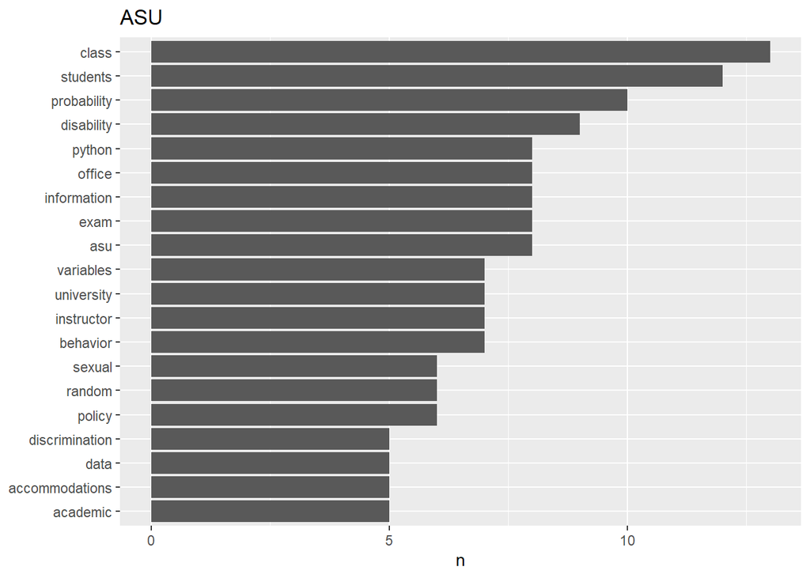

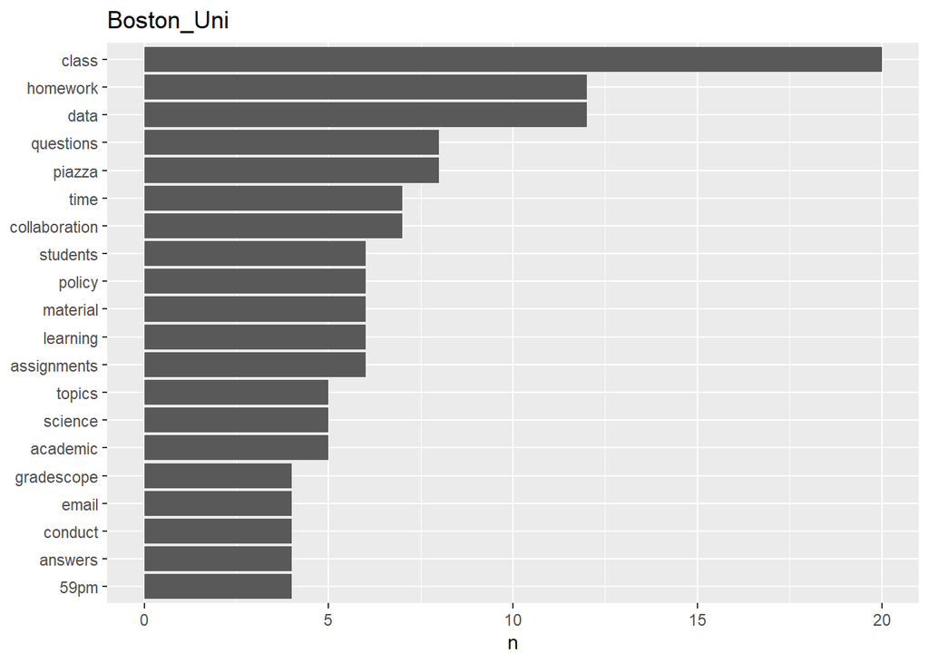

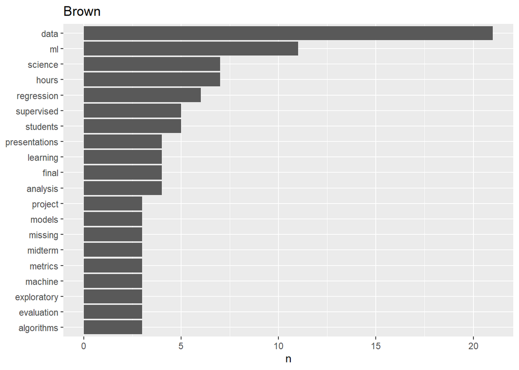

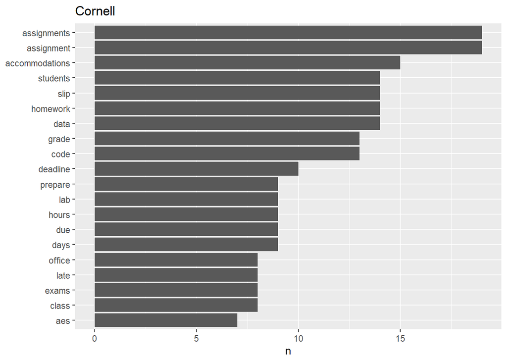

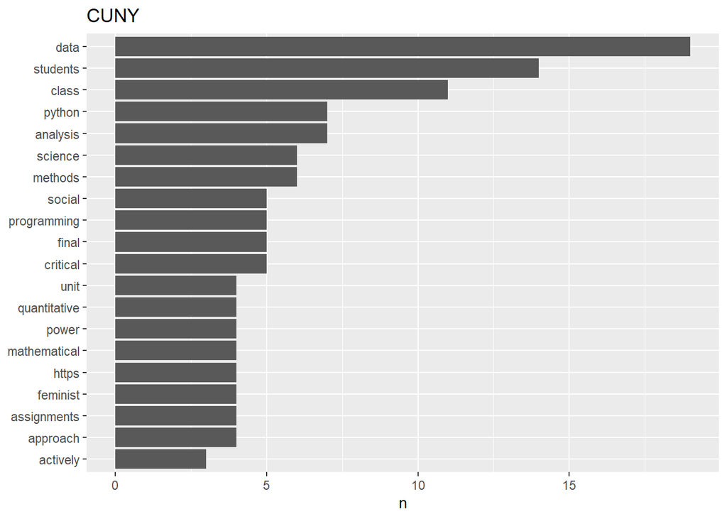

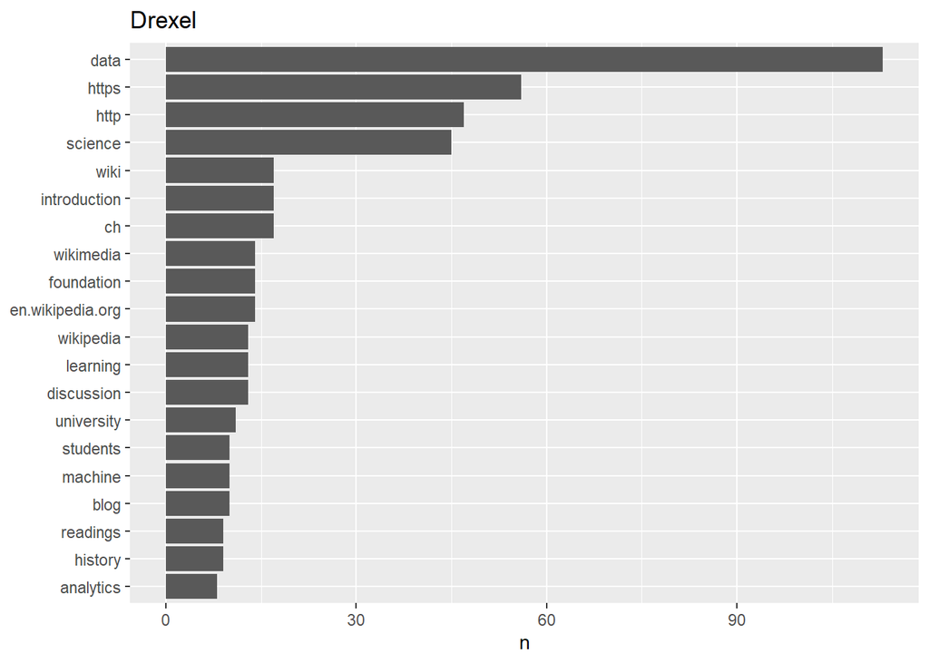

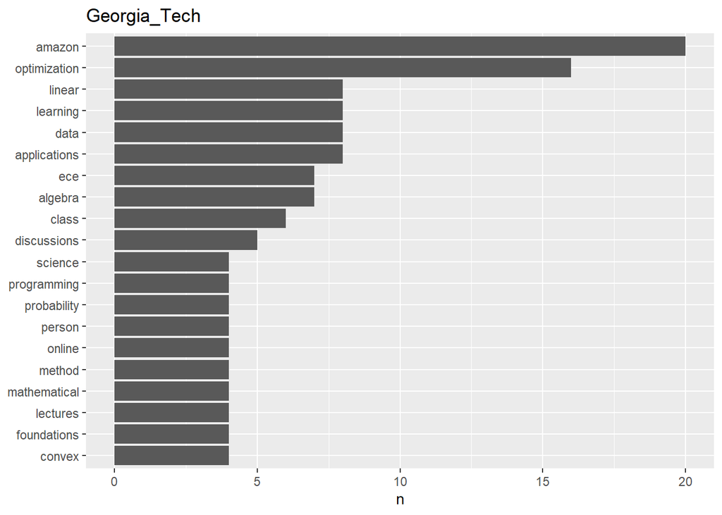

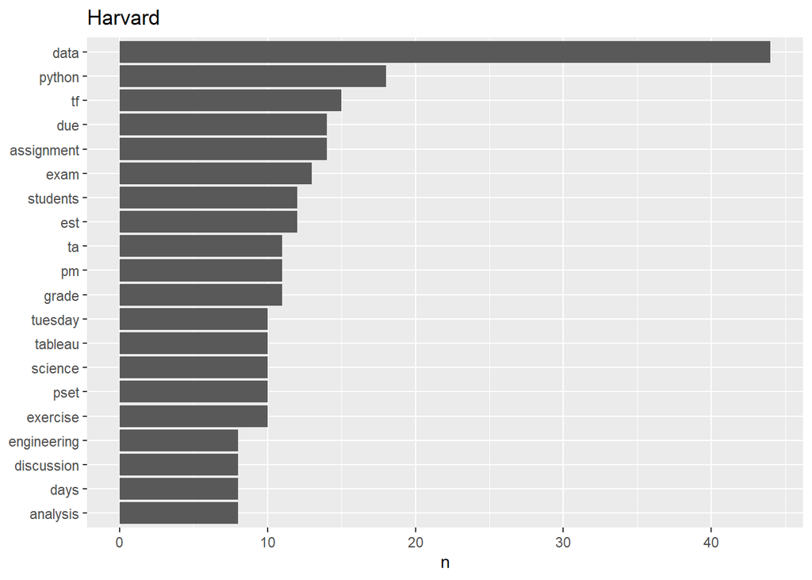

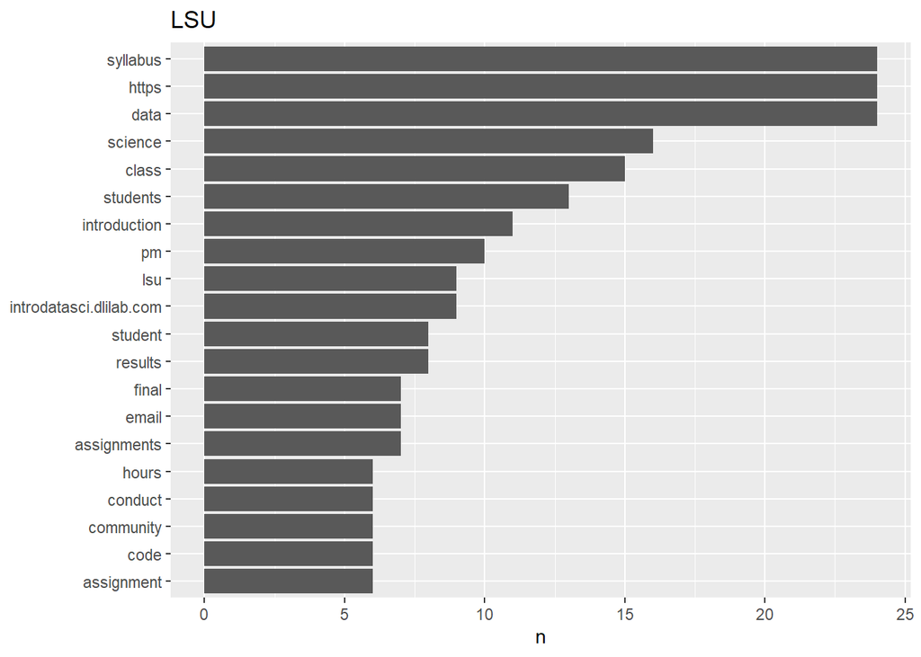

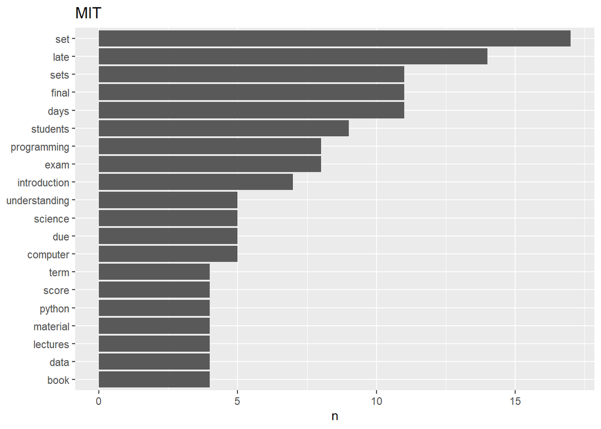

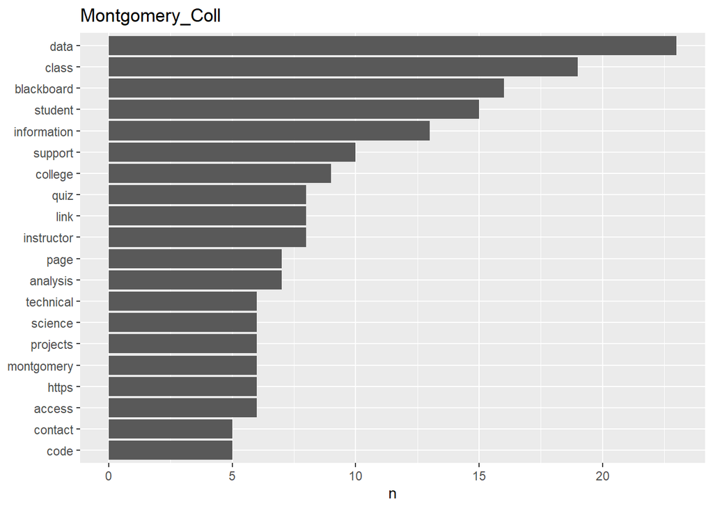

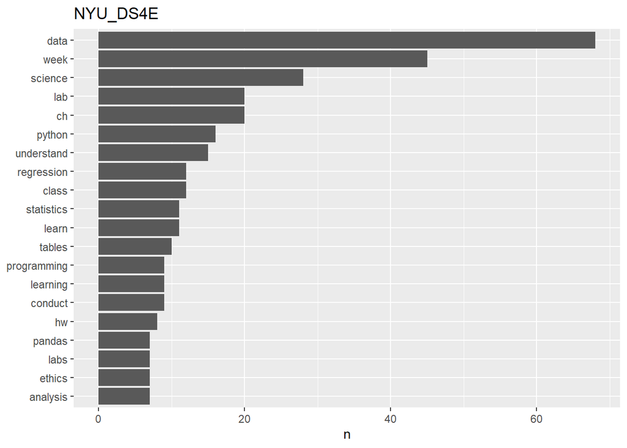

[23 more figures not shown]

```r
for (i in seq_along(df_list)) {
  print(df_list[[i]] %>%
    count(word, sort = TRUE) %>%
    head(k) %>%
    mutate(word = reorder(word, n)) %>%
    ggplot(aes(word, n)) +
    geom_col() +
    xlab(NULL) +
    coord_flip() +
    ggtitle(schools[i]))
}
```


```
## [1] "ASU"
```

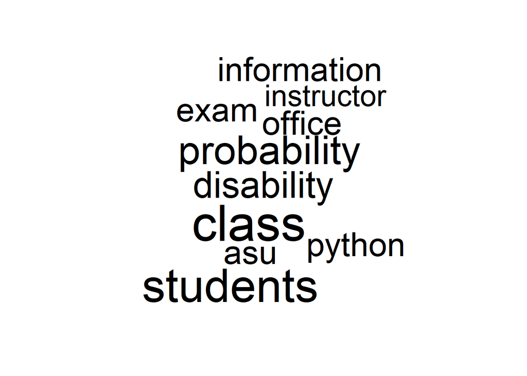

```
## [1] "Boston_Uni"
```

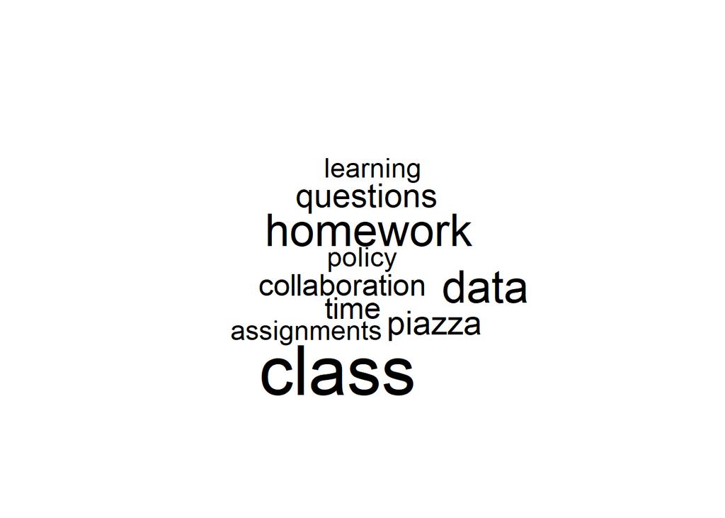

```
## [1] "Brown"
```

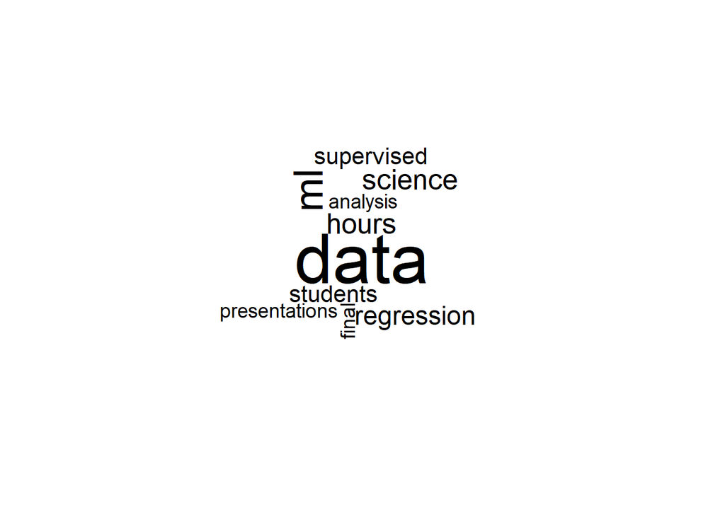

```
## [1] "Cornell"
```

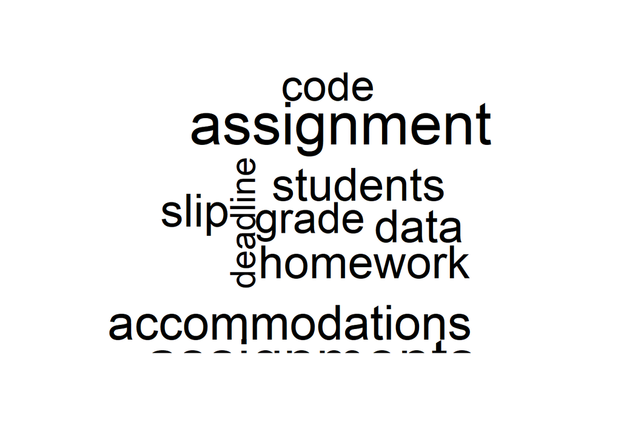

```
## [1] "CUNY"
```

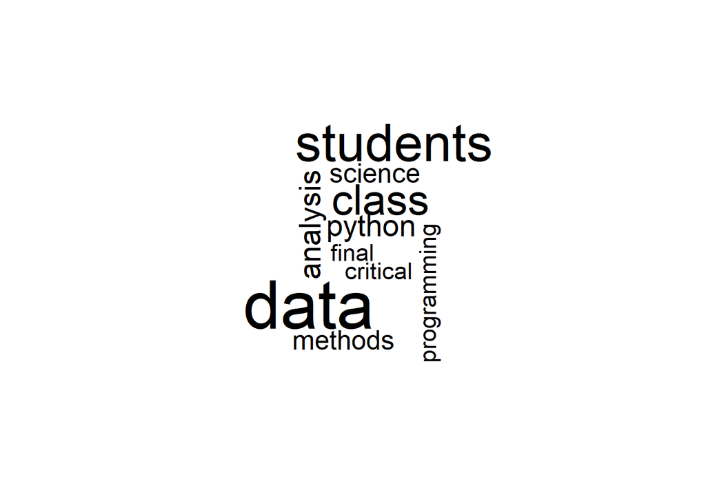

```
## [1] "Drexel"
```

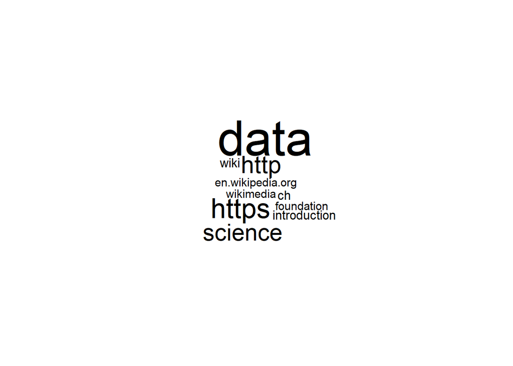

```
## [1] "Georgia_Tech"
```

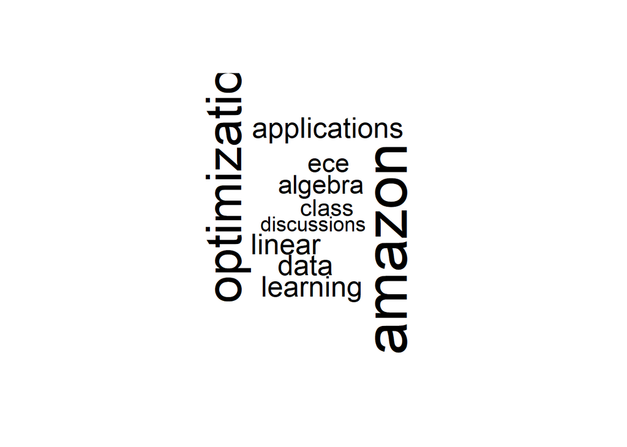

```
## [1] "Harvard"
```

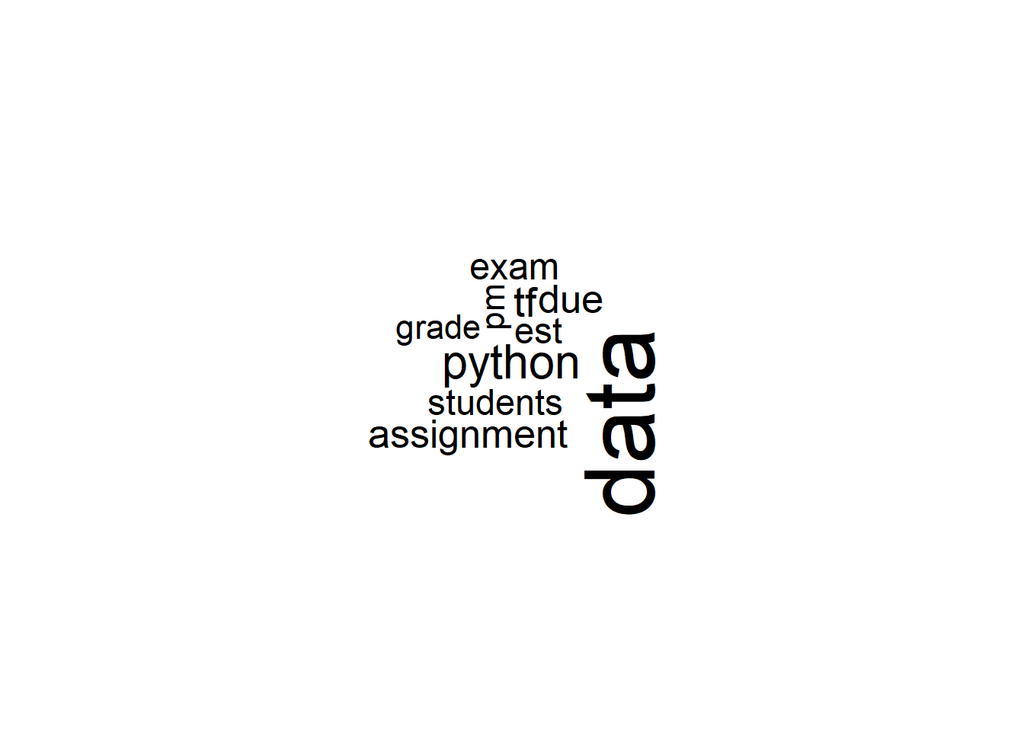

```
## [1] "LSU"
```

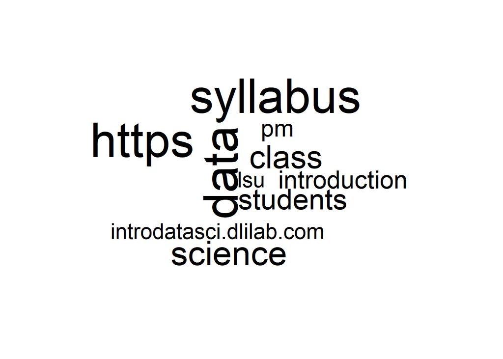

```
## [1] "MIT"
```

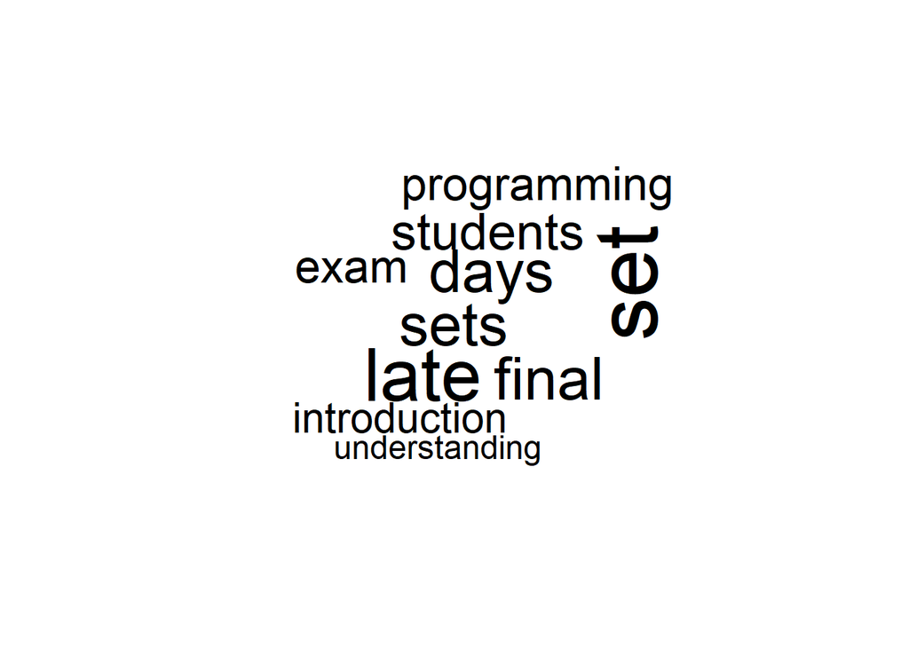

```
## [1] "Montgomery_Coll"
```

[figure not shown]

```
## [1] "NYU_DS4E"
```

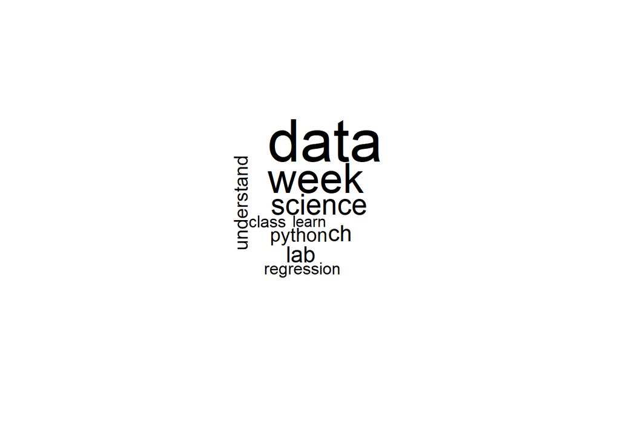

```
## [1] "NYU_IntroDS"
```

[23 more figures not shown]

```r
for (i in seq_along(df_list)) {
  print(schools[i])
  df_list[[i]] %>%
  count(word) %>%
  with(wordcloud(word, n, min.freq=4, max.words = 10))
}
```